# Bird of the year

BMH

22 November 2019

### loading the data from the Tidy Tuesday Github repo

```r
nz_bird <- read_csv("https://raw.githubusercontent.com/rfordatascience/tidytuesday/master/data/2019/2019-11-19/nz_bird.csv")
```

This is the NewZeland Bird of the year voting contest. we will try to analyze and find out who is the winner, and why? *probably more stuff to figure later*

### How many breeds do we have?

```r
nz_bird %>%
  count(bird_breed, sort = T)
```

```
## # A tibble: 86 x 2
##    bird_breed              n
##    <chr>               <int>
##  1 Yellow-eyed penguin 12022
##  2 <NA>                11834
##  3 Kākāpō              11161
##  4 Black Robin          8304
##  5 Kākā                 7655
##  6 Banded Dotterel      6692
##  7 Kea                  6364
##  8 Tūī                  6288
##  9 Blue Duck            6194
## 10 Fantail              6120
## # … with 76 more rows
```

```r
nz_bird %>%
  count(bird_breed, sort = T) %>% nrow()
```

```
## [1] 86
```

### How is the voting is distributed over hours?

```r
nz_bird %>%
  count(hour, sort = T)
```

```
## # A tibble: 24 x 2
##     hour     n
##    <dbl> <int>
##  1    14 16495
##  2    12 16390
##  3     9 16165
##  4    13 15755
##  5    11 15675
##  6    10 15410
##  7    15 13215
##  8    16 12760
##  9    20 11475
## 10    21 11465
## # … with 14 more rows
```

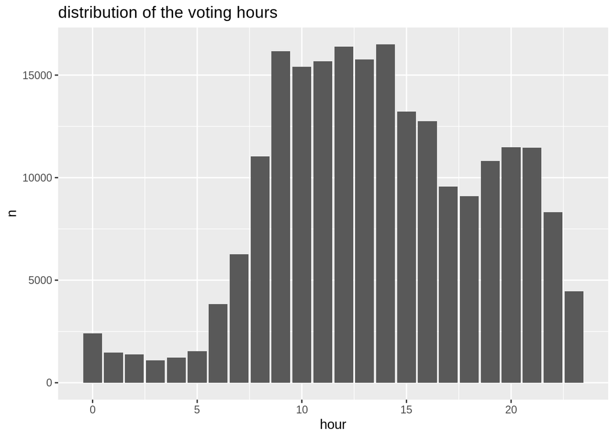

```r
nz_bird %>%
  count(hour, sort = T) %>%
  ggplot(aes(x = hour, y = n)) +
  geom_col() +
  labs(title = "distribution of the voting hours")
```

### What is the range of the voing period(in days)?

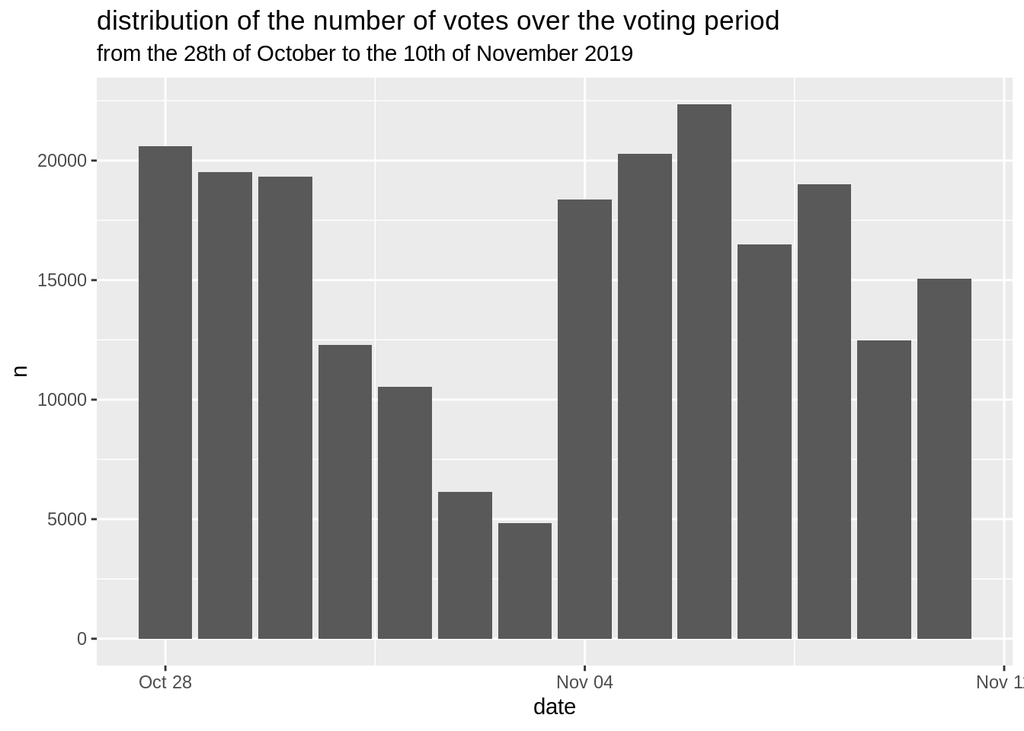

```r
nz_bird %>%
  count(date, sort = T) %>%
  ggplot(aes(x = date , y = n)) +
  geom_col() +
  labs(title = "distribution of the number of votes over the voting period",
       subtitle = "from the 28th of October to the 10th of November 2019")
```

## Objective

We need to develop a program that reads this data set and do the calculations for each round in order to rank the birds according to the given votes. To do this we need first to understand how does the IRV system works.

#### **Instatnt runoff voting system:**

1/ A voter ranks the candidates in order of preference

2/ The votes are assigned to the top ranked bird on each ballot

3/ The bird with the fewest votes is eliminated and those votes are transferred to their second choices

4/ This process is repeated until a candidate has a majority or only two candidates remain

```r
nz_bird %>%
  filter(vote_rank == "vote_1") %>%
  count(bird_breed, sort = T)
```

```
## # A tibble: 85 x 2
##    bird_breed               n
##    <chr>                <int>
##  1 Yellow-eyed penguin   5757
##  2 Kākāpō                3386
##  3 Banded Dotterel       1866
##  4 Fantail               1829
##  5 Black Robin           1759
##  6 Antipodean Albatross  1504
##  7 Blue Duck             1469
##  8 Kererū                1437
##  9 New Zealand Falcon    1348
## 10 Kea                   1311
## # … with 75 more rows
```

```r
nz_bird %>%
  filter(vote_rank == "vote_2") %>%
  count(bird_breed, sort = T)
```

```
## # A tibble: 86 x 2
##    bird_breed              n
##    <chr>               <int>
##  1 <NA>                 2270
##  2 Kākāpō               2084
##  3 Black Robin          1978
##  4 Yellow-eyed penguin  1729
##  5 Banded Dotterel      1685
##  6 Kākā                 1580
##  7 Kea                  1419
##  8 Blue Duck            1263
##  9 Fantail              1249
## 10 Tūī                  1214
## # … with 76 more rows
```

```r
nz_bird %>%
  filter(vote_rank == "vote_3") %>%
  count(bird_breed, sort = T)
```

```
## # A tibble: 86 x 2
##    bird_breed              n
##    <chr>               <int>
##  1 <NA>                 2635
##  2 Kākāpō               2056
##  3 Black Robin          1772
##  4 Kākā                 1743
##  5 Yellow-eyed penguin  1408
##  6 Kea                  1376
##  7 Tūī                  1266
##  8 Banded Dotterel      1234
##  9 Kererū               1222
## 10 Blue Duck            1182
## # … with 76 more rows
```

```r
nz_bird %>%
  filter(vote_rank == "vote_4") %>%
  count(bird_breed, sort = T)
```

```
## # A tibble: 86 x 2
##    bird_breed              n
##    <chr>               <int>
##  1 <NA>                 3169
##  2 Kākāpō               1957
##  3 Kākā                 1667
##  4 Black Robin          1526
##  5 Yellow-eyed penguin  1425
##  6 Tūī                  1322
##  7 Morepork             1251
##  8 Kea                  1216
##  9 Blue Duck            1187
## 10 New Zealand Falcon   1186
## # … with 76 more rows
```

```r
nz_bird %>%
  filter(vote_rank == "vote_5") %>%
  count(bird_breed, sort = T)
```

```
## # A tibble: 86 x 2
##    bird_breed                  n
##    <chr>                   <int>
##  1 <NA>                     3760
##  2 Yellow-eyed penguin      1703
##  3 Kākāpō                   1678
##  4 Kākā                     1476
##  5 Tūī                      1365
##  6 Morepork                 1342
##  7 Black Robin              1269
##  8 Orange-fronted Parakeet  1119
##  9 New Zealand Falcon       1110
## 10 Blue Duck                1093
## # … with 76 more rows
```

After some thinking I do not think this is the tidy version of this data. We need 5 columns indicating the rank choice of each breed, which gives us one observation (vote) per row.

We do not really have NAs in our dataset, the NAs presented are because Voters do not have to give full ranked lists.

After 3 hours of trying to figure how to spread the data using tidyr, I gave up and went back to the main repo to find out that the author used a developer function in tidyr “pivot_longer” to make it into this shape, and while I couldn’t install that version of the tidyr to use the opposit function “tidy_wider”, I just realized that I can just load the non modified original data, form the same repo. DEPRESSIVE.

```r
data <- read_csv("https://raw.githubusercontent.com/rfordatascience/tidytuesday/master/data/2019/2019-11-19/BOTY-votes-2019.csv") %>% select(-country)
```

NOW THIS IS THE DATA I WANT.

Let’s Investigate more. We have 43460 vote (that is a list of ranked 5 birds), this means that to have a winning bird, it needs to have 21730 votes.

```r
rank_bird <- nz_bird %>%
  count(bird_breed, vote_rank, sort = T) %>%
  spread(vote_rank, n) %>%
  mutate(t_votes = rowSums(nz_bird %>%
                                  count(bird_breed, vote_rank, sort = T) %>%
                                  spread(vote_rank, n) %>%
                                  select(-bird_breed), na.rm = F )) %>%
  mutate(percentage = t_votes*100/43460) %>%
  arrange(desc(t_votes))

rank_bird
```

```
## # A tibble: 86 x 8
##    bird_breed          vote_1 vote_2 vote_3 vote_4 vote_5 t_votes percentage
##    <chr>                <int>  <int>  <int>  <int>  <int>   <dbl>      <dbl>
##  1 Yellow-eyed penguin   5757   1729   1408   1425   1703   12022       27.7
##  2 Kākāpō                3386   2084   2056   1957   1678   11161       25.7
##  3 Black Robin           1759   1978   1772   1526   1269    8304       19.1
##  4 Kākā                  1189   1580   1743   1667   1476    7655       17.6
##  5 Banded Dotterel       1866   1685   1234   1025    882    6692       15.4
##  6 Kea                   1311   1419   1376   1216   1042    6364       14.6
##  7 Tūī                   1121   1214   1266   1322   1365    6288       14.5
##  8 Blue Duck             1469   1263   1182   1187   1093    6194       14.3
##  9 Fantail               1829   1249   1052    972   1018    6120       14.1
## 10 New Zealand Falcon    1348   1204   1144   1186   1110    5992       13.8
## # … with 76 more rows
```

The most voted for bird do not have a majority, therefore we need a new round of computation. It is also important to note that the NAs which represent almost 27% of the gven votes are exhausted (eliminated)

#### *Using “votesys”*

I am going to use the votesys library which is specialized in voting systems. and appearantly we have a winner after 79 rounds.

The irv_method function, recieves a vote object, so the first thing to do is to prepare our votig data to get there.

#### Creating a names vector of candidate birds to pass to the function creat_vote which match names and votes and create a condorcet matrix (I studied condorcet’s theory in undergrad in microeconomics XD).

```r
library(votesys)
# create a vector of candidates names (+ NAs do not count)
n_birds <- nz_bird %>%
  count(bird_breed) %>%
  pull(bird_breed) %>%
  .[-1]

n_birds
```

```
##  [1] "Antipodean Albatross"            "Arctic Skua"
##  [3] "Australasian Crested Grebe"      "Australasian Gannet"
##  [5] "Banded Dotterel"                 "Bar-tailed Godwit"
##  [7] "Barn Owl"                        "Bellbird"
##  [9] "Bittern"                         "Black Petrel"
## [11] "Black Robin"                     "Black shag"
## [13] "Black Stilt"                     "Black-billed Gull"
## [15] "Black-fronted Tern"              "Blue Duck"
## [17] "Brown Teal"                      "Buller's Mollymawk"
## [19] "Campbell Black-Browed Albatross" "Chatham Island Mollymawk"
## [21] "Chatham Island Oystercatcher"    "Fairy Tern"
## [23] "Fantail"                         "Fernbird"
## [25] "Fiordland Crested Penguin"       "Gibson's Albatross"
## [27] "Great Spotted Kiwi"              "Grey Duck"
## [29] "Grey Warbler"                    "Harrier"
```

[output cut: 28 more lines]

Now we pass the names to the create_vote function to induce it to the irv_method function to get to know the coolest of birds.

```r
# creating a data frame of only the votes for the candidates to induce it into
# a condorcet matrix with create_vote
# the IRV calculation function(which is slow)
# I will call this iteration : cool_bird
cool_bird <- data %>%
  select(-date, -hour) %>%
  as.data.frame() %>%
  create_vote(., candidate = n_birds) %>%
  irv_method(.)
```

[output not shown]

[output not shown]

[output not shown]

[output not shown]

[output not shown]

[output not shown]

[output not shown]

[output not shown]

[output not shown]

[output not shown]

[output not shown]

[output not shown]

[output not shown]

[output not shown]

[output not shown]

[output not shown]

[output not shown]

[output not shown]

[output not shown]

[output not shown]

[output not shown]

[output not shown]

[output not shown]

[output not shown]

[output not shown]

[output not shown]

[output not shown]

[output not shown]

[output not shown]

[output not shown]

[output not shown]

[output not shown]

[output not shown]

[output not shown]

[output not shown]

[output not shown]

[output not shown]

[output not shown]

[output not shown]

[output not shown]

[output not shown]

[output not shown]

[output not shown]

[output not shown]

[output not shown]

[output not shown]

[output not shown]

[output not shown]

[output not shown]

[output not shown]

[output not shown]

[output not shown]

[output not shown]

[output not shown]

[output not shown]

[output not shown]

[output not shown]

[output not shown]

[output not shown]

[output not shown]

[output not shown]

[output not shown]

[output not shown]

[output not shown]

[output not shown]

[output not shown]

[output not shown]

[output not shown]

[output not shown]

[output not shown]

[output not shown]

[output not shown]

[output not shown]

[output not shown]

[output not shown]

[output not shown]

[output not shown]

[output not shown]

[output not shown]

[output not shown]

[output not shown]

[output not shown]

[output not shown]

[output not shown]

[output not shown]

[output not shown]

[output not shown]

To resume the voting process we need some informations which are given in the ouput of the function. It would be nice to Know:

```
* The cooles of birds(obviously) and the vice cool bird.
* The number of rounds to get the winning bird a majority.
* The number of votes for both
```

```r
n_rounds <- cool_bird$other_info %>% length()

final_birds <- cool_bird$other_info[n_rounds] %>%
  as.data.frame() %>%
  rename(birdy = Var1, n_votes = Freq) %>%
  mutate(n_rounds = n_rounds,
         abolute = cool_bird$absolute,
         winner = c(FALSE, TRUE))
final_birds
```

```
##                 birdy n_votes n_rounds abolute winner
## 1              Kākāpō    9776       79   FALSE  FALSE
## 2 Yellow-eyed penguin   10743       79   FALSE   TRUE
```

There You have it folks, loud and clear, we have a winner, with yellow eyes.

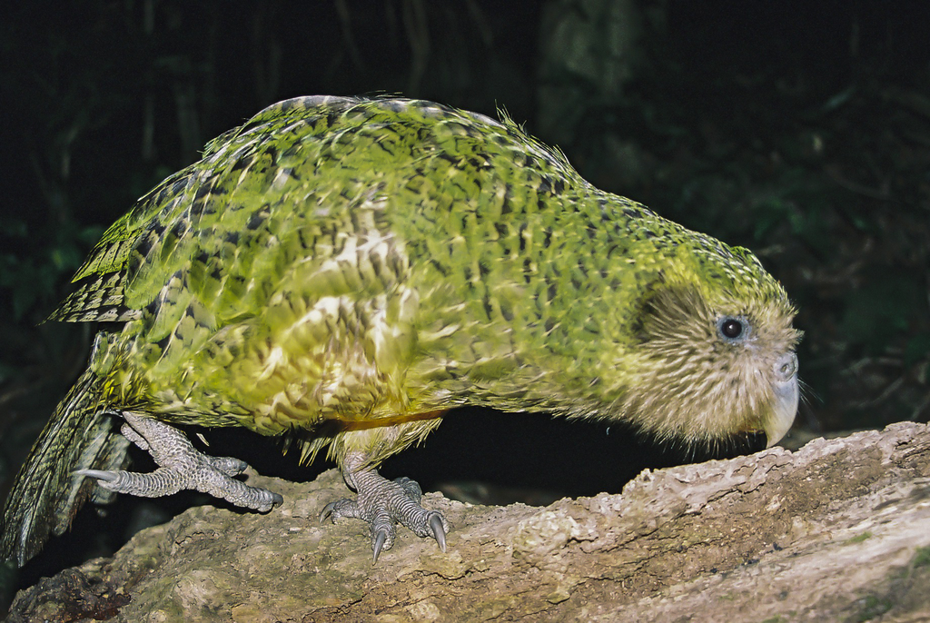

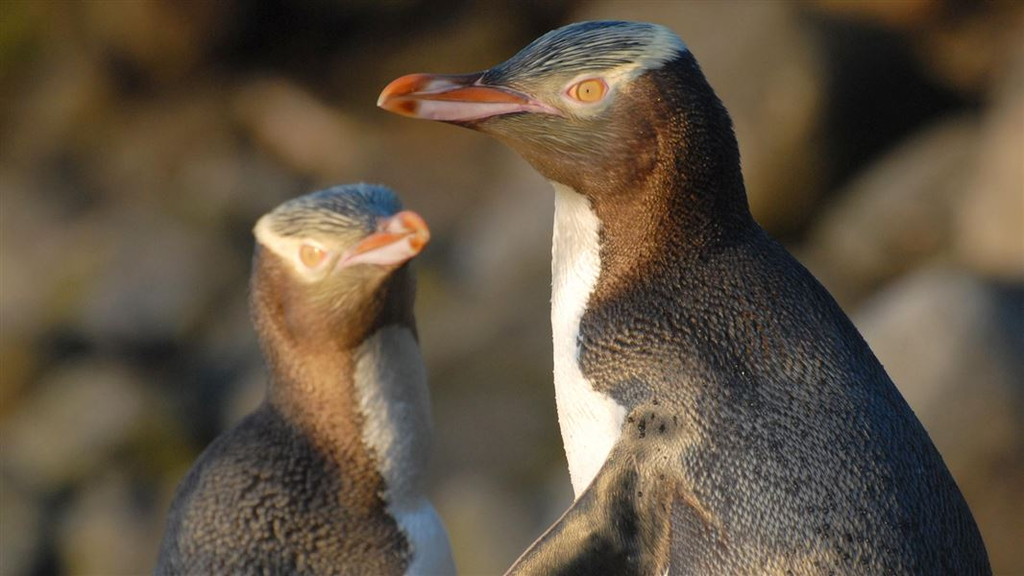